# Hw5

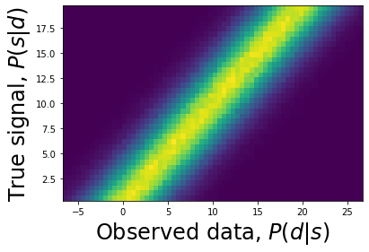

```python
import numpy as np
import matplotlib
import matplotlib.pyplot as plt
import scipy
from scipy import stats


bkgd = stats.norm.rvs(scale=3, size=1000000)
signal = np.random.uniform(size=1000000, low=0, high=20)

data = bkgd + signal

signaledges = np.linspace(0,20,40)
dataedges = np.linspace(-7,27,68)

Psd, temp, temp2= np.histogram2d(data,signal, bins=[dataedges,signaledges], density=True)

datacenters = (dataedges[:-1] + dataedges[1:]) / 2
signalcenters = (signaledges[:-1] + signaledges[1:]) / 2
plt.pcolormesh(datacenters,signalcenters,Psd.T)
plt.ylabel('True signal, $P(s|d)$', fontsize = 24)
plt.xlabel('Observed data, $P(d|s)$', fontsize = 24)
```

```
10.256410256410255
```

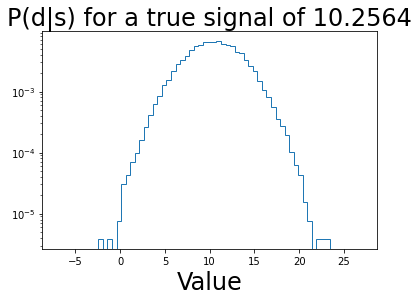

```python
# Problem 1.B
# Choose injected signal of 10.2564
print(temp2[20])
slice = Psd[:,20]
plt.stairs(slice, temp)
plt.title('P(d|s) for a true signal of 10.2564', fontsize=24)
plt.xlabel('Value', fontsize=24)
plt.yscale('log')
plt.show()
```

Problem 1.B

This plot is a slice of the 2d Histogram above, it shows the probability densities of all the data values where the injected signal is equal to 10.2564. This means that it if we get a true signal value of 10.2564, this graph shows that probabilities that an observed data value would result in that signal.

```
9.746268656716417
```

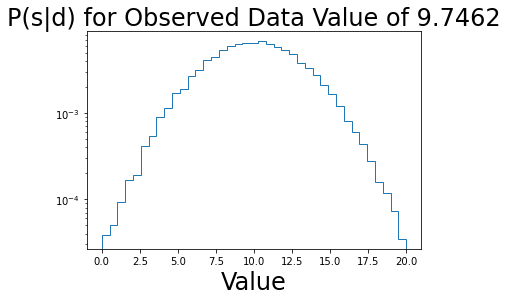

```python
# Problem 1.C
# Choose observed data value of 9.7462
print(temp[33])
slice = Psd[33,:]
plt.stairs(slice, temp2)
plt.title('P(s|d) for Observed Data Value of 9.7462', fontsize=24)
plt.xlabel('Value', fontsize=24)
plt.yscale('log')
plt.show()
```

Problem 1.C

This plot takes a vertical slice of the 2d Histogram above, and represents the probability distribution of all possible signal values, when an observed data point is equal to the value of 9.7462

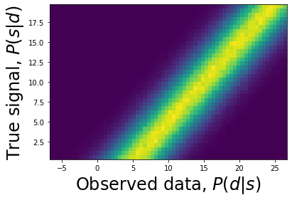

```python
# Problem 2

bkgd = stats.norm.rvs(scale=3, size=1000000, loc=5)
signal = np.random.uniform(size=1000000, low=0, high=20)

data = bkgd + signal

signaledges = np.linspace(0,20,40)
dataedges = np.linspace(-7,27,68)

Psd, temp, temp2= np.histogram2d(data,signal, bins=[dataedges,signaledges], density=True)

datacenters = (dataedges[:-1] + dataedges[1:]) / 2
signalcenters = (signaledges[:-1] + signaledges[1:]) / 2
plt.pcolormesh(datacenters,signalcenters,Psd.T)
plt.ylabel('True signal, $P(s|d)$', fontsize = 24)
plt.xlabel('Observed data, $P(d|s)$', fontsize = 24)
```

[figure not shown]

```python
# Choose injected signal of 15.2564
slice = Psd[:,20]
plt.stairs(slice, temp)
plt.title('P(d|s) for a true signal of 10.2564', fontsize=24)
plt.xlabel('Value', fontsize=24)
plt.show()
```

Problem 2

This plot is a slice of the 2d Histogram above, it shows the probability densities of all the data values where the injected signal is equal to 10.2564. This means that it if we get a true signal value of 10.2564, this graph shows that probabilities that an observed data value would result in that signal. This plot is shifted from the first one because the mean of the background distribution was shifted over by 5.

[figure not shown]

```python
# Choose observed data value of 15.2564
slice = Psd[33,:]
plt.stairs(slice, temp2)
plt.title('P(s|d) for Observed Data Value of 10.2564', fontsize=24)
plt.xlabel('Value', fontsize=24)
plt.show()
```

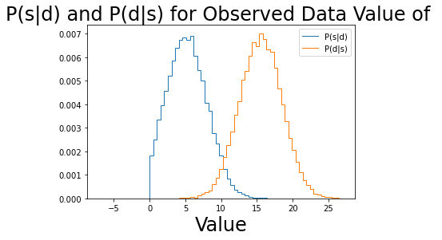

```python
# Choose observed data value of 15.2564
slice2 = Psd[33,:]
slice1 = Psd[:,20]
plt.stairs(slice2, temp2, label='P(s|d)')
plt.stairs(slice1, temp, label='P(d|s)')
plt.title('P(s|d) and P(d|s) for Observed Data Value of 10.2564', fontsize=24)
plt.xlabel('Value', fontsize=24)
plt.legend()
plt.show()
```

It can be seen in the plot above that both of these graphs are not the same. They are reflected around the actual value being looked at, because the background distribution was offset by 5, they are shifted by plus and minus 5.